# 第2回: Mixed model

2018-04-23 16:00–

## Mixed model

[Environmental computing の mixed-model のページ](http://environmentalcomputing.net/mixed-models/)

- random variable

4 criteria

- is categorical
- has a large number of levels
- only a random subsample of levels is included in your design
- you want to make inference in general, and not only for the levels you observed.

薬学とかで使われる

Assumptions

1. The observed $y$ are independent, conditional on some predictors $x$
2. The response $y$ are normally distributed conditional on some predictors $x$
3. The response $y$ has constant variance, conditional on some predictors $x$
4. There is a straight line relationship between $y$ and the predictors $x$ and random effects $z$
5. Random effects $z$ are independent of $y$.
6. Random effects $z$ are normally distributed

```r
library(lme4)
```

```r
n <- 15
```

正規分布の乱数

```r
?rnorm()
```

- seed を設定して乱数の値を固定する

```r
set.seed(10)
rnorm(n, mean = 0, sd = 1)
```

```
 [1]  0.01874617 -0.18425254 -1.37133055
 [4] -0.59916772  0.29454513  0.38979430
 [7] -1.20807618 -0.36367602 -1.62667268
[10] -0.25647839  1.10177950  0.75578151
[13] -0.23823356  0.98744470  0.74139013
```

```r
set.seed(10)
rnorm(n, mean = 0, sd = 1)
```

```
 [1]  0.01874617 -0.18425254 -1.37133055
 [4] -0.59916772  0.29454513  0.38979430
 [7] -1.20807618 -0.36367602 -1.62667268
[10] -0.25647839  1.10177950  0.75578151
[13] -0.23823356  0.98744470  0.74139013
```

- data.frame の作成

```r
site_effect <- rnorm(n, mean=0, sd=1)
y1 <- site_effect + rnorm(n, mean=0, sd=1)
y2 <- site_effect + 6 + rnorm(n, mean=0, sd=1)
myDat <- data.frame(
  y = c(y1, y2),
  treatment = c(rep("control", n), rep("fertil", n)),
  site = rep(paste0("S", seq(1:n)), 2)
  )
str(myDat)
```

```
'data.frame':   30 obs. of  3 variables:
 $ y        : num  -1.764 -1.033 0.773 1.11 -0.897 ...
 $ treatment: Factor w/ 2 levels "control","fertil": 1 1 1 1 1 1 1 1 1 1 ...
 $ site     : Factor w/ 15 levels "S1","S10","S11",..: 1 8 9 10 11 12 13 14 15 2 ...
```

```r
head(myDat)
```

|  | y | treatment | site |
| --- | --- | --- | --- |
| 1 | -1.7643932 | control | S1 |
| 2 | -1.0328899 | control | S2 |
| 3 | 0.7734160 | control | S3 |
| 4 | 1.1104472 | control | S4 |
| 5 | -0.8969651 | control | S5 |
| 6 | -2.0318250 | control | S6 |

- mixed model
- 固定効果: treatment
- ランダム効果: site

```r
mod1 <- lmer(y ~ treatment + (1|site), data = myDat, REML=FALSE)
mod1
```

```
Linear mixed model fit by maximum likelihood [
lmerMod]
Formula: y ~ treatment + (1 | site)
   Data: myDat
     AIC      BIC   logLik deviance df.resid
 95.9756 101.5804 -43.9878  87.9756       26
Random effects:
 Groups   Name        Std.Dev.
 site     (Intercept) 0.4265
 Residual             0.9655
Number of obs: 30, groups:  site, 15
Fixed Effects:
    (Intercept)  treatmentfertil
         -1.026            6.655
```

- Random effects の sd は 1 ぐらいになる
- 乱数発生時のパラメータ
- treatmentfertil の Estimate: 6 ぐらいになる
- データを作ったときの値
- p-value がない!

```r
summary(mod1)
```

```
Linear mixed model fit by maximum likelihood [
lmerMod]
Formula: y ~ treatment + (1 | site)
   Data: myDat

     AIC      BIC   logLik deviance df.resid
    96.0    101.6    -44.0     88.0       26

Scaled residuals:
    Min      1Q  Median      3Q     Max
-1.7973 -0.6020 -0.2085  0.4798  1.8119

Random effects:
 Groups   Name        Variance Std.Dev.
 site     (Intercept) 0.1819   0.4265
 Residual             0.9323   0.9655
Number of obs: 30, groups:  site, 15

Fixed effects:
                Estimate Std. Error t value
(Intercept)      -1.0258     0.2725  -3.764
treatmentfertil   6.6549     0.3526  18.875

Correlation of Fixed Effects:
            (Intr)
tretmntfrtl -0.647
```

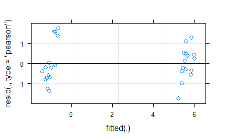

```r
plot(mod1)
```

- p値の算出

```r
mod2<- lmer(y ~ 1 + (1|site), data = myDat, REML=FALSE)
mod2
```

```
Linear mixed model fit by maximum likelihood [
lmerMod]
Formula: y ~ 1 + (1 | site)
   Data: myDat
     AIC      BIC   logLik deviance df.resid
166.1451 170.3487 -80.0726 160.1451       27
Random effects:
 Groups   Name        Std.Dev.
 site     (Intercept) 0.000
 Residual             3.491
Number of obs: 30, groups:  site, 15
Fixed Effects:
(Intercept)
      2.302
```

```r
anova(mod1, mod2)
```

```
Data: myDat
Models:
mod2: y ~ 1 + (1 | site)
mod1: y ~ treatment + (1 | site)
     Df     AIC    BIC  logLik deviance  Chisq
mod2  3 166.145 170.35 -80.073  160.145
mod1  4  95.976 101.58 -43.988   87.976 72.169
     Chi Df Pr(>Chisq)
mod2
mod1      1  < 2.2e-16 ***
---
Signif. codes:
0 ‘***’ 0.001 ‘**’ 0.01 ‘*’ 0.05 ‘.’ 0.1 ‘ ’ 1
```

モデルの中身の取り出し

- `broom` package

```r
library(broom)
```

```r
tidy(mod1)
```

| term | estimate | std.error | statistic | group |
| --- | --- | --- | --- | --- |
| (Intercept) | -1.0257653 | 0.2725462 | -3.763638 | fixed |
| treatmentfertil | 6.6548783 | 0.3525671 | 18.875493 | fixed |
| sd_(Intercept).site | 0.4265497 | NA | NA | site |
| sd_Observation.Residual | 0.9655448 | NA | NA | Residual |

```r
library(dplyr)
```

```r
tidy(mod1) %>%
  filter(term=="treatmentfertil") -> output
output$estimate
```

```
[1] 6.654878
```

- 関数

```r
power_analysis <- function(n){
  site_effect <- rnorm(n, mean=0, sd=1)
  y1 <- site_effect + rnorm(n, mean=0, sd=1)
  y2 <- site_effect + 6 + rnorm(n, mean=0, sd=1)
  myDat <- data.frame(
    y = c(y1, y2),
    treatment = c(rep("control", n), rep("fertil", n)),
    site = rep(paste0("S", seq(1:n)), 2)
    )
  mod1 <- lmer(y ~ treatment + (1|site), data = myDat, REML=FALSE)
  tidy(mod1) %>%
    filter(term=="treatmentfertil") -> output
  return(output$estimate)
}
power_analysis(5)
```

```
[1] 5.081315
```

```r
power_analysis(2)
```

```
[1] 7.79872
```

n=1 だとエラー

```r
power_analysis(1)
```

```
Error: grouping factors must have > 1 sampled level
```

- 6に収束

```r
for (i in c(1:10)){
  n <- 2**i
  print(power_analysis(n))
}
```

```
[1] 3.930908
[1] 6.642802
[1] 5.819684
[1] 5.543689
[1] 6.01089
[1] 5.870242
[1] 6.007282
[1] 6.063773
[1] 6.091069
[1] 6.036328
```

```r
coef(mod1)
```

```
$site
    (Intercept) treatmentfertil
S1   -1.0688887        6.654878
S10  -1.2053688        6.654878
S11  -0.6717173        6.654878
S12  -1.2564258        6.654878
S13  -1.1160846        6.654878
S14  -0.8318127        6.654878
S15  -0.9959467        6.654878
S2   -1.0761104        6.654878
S3   -0.7908244        6.654878
S4   -0.6390412        6.654878
S5   -0.7958519        6.654878
S6   -1.2548684        6.654878
S7   -1.4393543        6.654878
S8   -1.0740829        6.654878
S9   -1.1701018        6.654878

attr(,"class")
[1] "coef.mer"
```

- 結果の違いをシミュレーションする

```r
data.frame(sample_size = rep(2:40, each=10)) %>%
  rowwise() %>%
  mutate(po = power_analysis(sample_size)) -> simulation
head(simulation)
```

| sample_size | po |
| --- | --- |
| 2 | 4.864322 |
| 2 | 5.611438 |
| 2 | 5.004403 |
| 2 | 5.989259 |
| 2 | 5.940648 |
| 2 | 4.294028 |

[output not shown]

```r
library(ggplot2)
```

- 6に収束

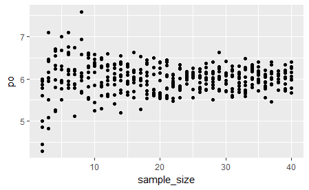

```r
ggplot(simulation, aes(x = sample_size, y = po)) +
  geom_point()
```

```r
compute_p <- function(n){
  site_effect <- rnorm(n, mean=0, sd=1)
  y1 <- site_effect + rnorm(n, mean=0, sd=1)
  y2 <- site_effect + 6 + rnorm(n, mean=0, sd=1)
  myDat <- data.frame(
    y = c(y1, y2),
    treatment = c(rep("control", n), rep("fertil", n)),
    site = rep(paste0("S", seq(1:n)), 2)
    )
  mod1 <- lmer(y ~ treatment + (1|site), data = myDat, REML=FALSE)
  mod2 <- lmer(y ~ 1 + (1|site), data = myDat, REML=FALSE)
  tst <- anova(mod1, mod2)
  tst %>%
    tidy() %>%
    filter(term=="mod1") -> output
  return(output[["p.value"]])
}
compute_p(5)
```

```
The following column names in ANOVA output were not recognized or transformed: AIC, BIC, logLik, deviance, Chi.Df
```

```
[1] 1.354022e-05
```

```r
suppressWarnings(
  data.frame(sample_size = rep(2:40, each=10)) %>%
    rowwise() %>%
    mutate(p.value = compute_p(sample_size)) -> simulation2
)
```

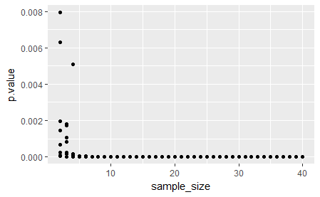

```r
ggplot(simulation2, aes(x = sample_size, y = p.value)) +
  geom_point()
```

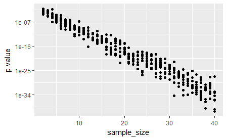

```r
ggplot(simulation2, aes(x = sample_size, y = p.value)) +
  geom_point() +
  scale_y_continuous(trans = "log10")
```